# Big youtube is watching

## What have YOU(tube) been watching?

Hi! welcome to my data story. I decided to collect data about YouTube. I collected data about the video I watched, such as how long it was, what genre it was and also the time of day. I also collected what device I was using.

YouTube is a daily occurrence for me, for a range of things from study, wind-down, cooking, and background/white noise, so it is cool to see the statistics that comes within it!

## WHAT genre do I love?

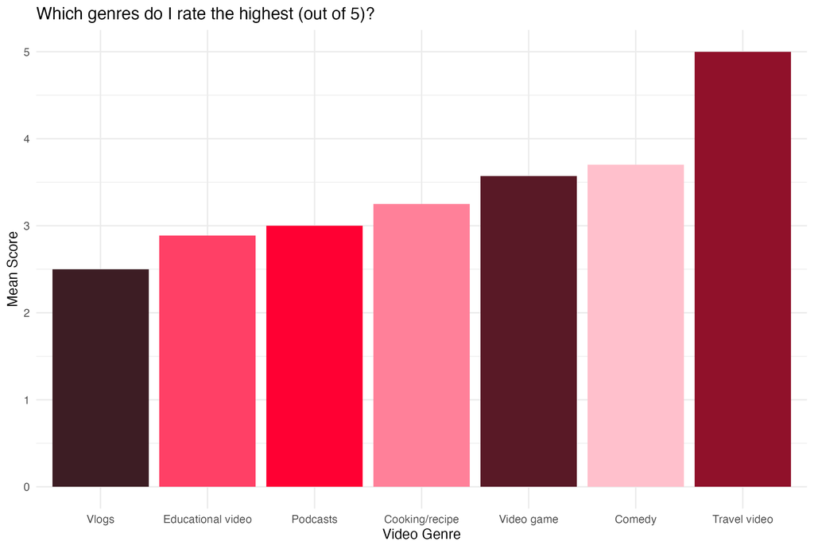

This barplot shows genres of youtube video on the x axis and the rating of the video on the Y axis

**Figure 1:** *showcasing the rating of genres with the mean score of likelyness.* Travel videos has the highest mean score while volgs has the shortest mean score. The score describes if I liked the video or not and if i would re-watch it. 1= Would not re-watch/did not like, 5 = loved it, would watch again.

This bar chart shows that I love travel videos, along with comedy. This plot also hows me that i tend to rate videos roughly around ~3, which probably means i am not very polarized within the genres i choose to watch. Vlogs are the lowest, which makes sense as I prefer not to re-watch vlogs, but re watching travel or comedy video is something I tend to do!

[figure not shown]

Cute orange and white cat laughing captioned with HEHE

## WHEN do I watch the videos?

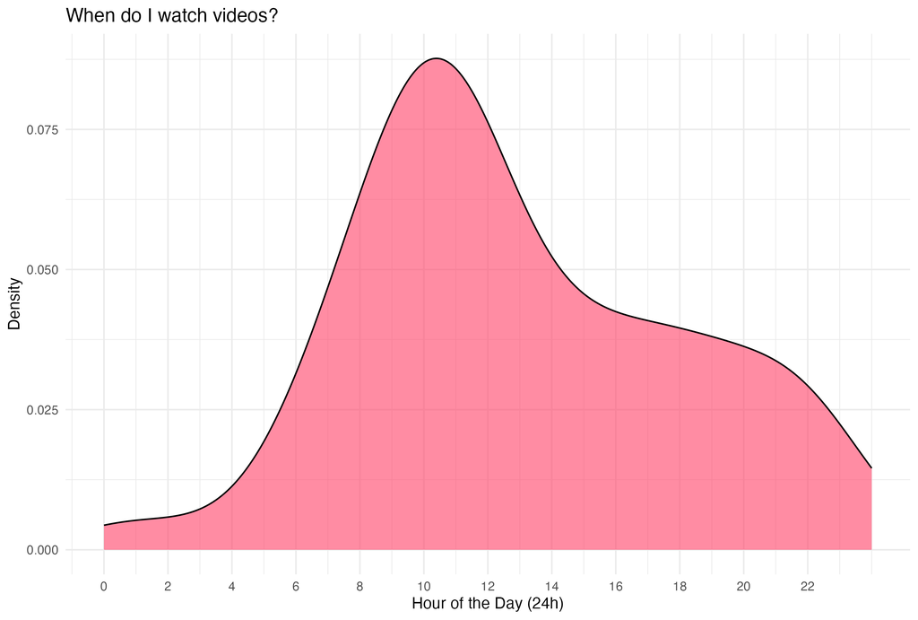

This shows a density plot of when I watched videos on a 24 hour axis

[figure not shown]

Cute gif of a white cat who is opening and closer their paws, with text underneath saying “GOOD MORNING” with a red heart

## WHEN do I watch the videos? part 2

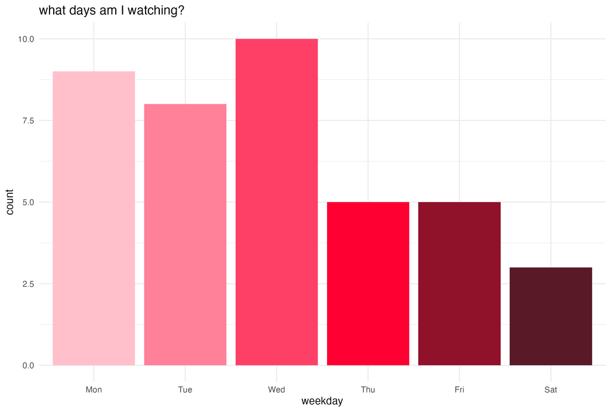

This shows a bar graph of when I watched videos on a week axis

**Figure 3:** *this graph shows what day I am watching the videos*. this shows me that i tend to watch videos more on the weekdays than the weekends. There also was no data during Sunday.

Damn! I guess I watch YouTube during the week, perhaps trying to avoid studying HAHA!. there was minimal videos watched on the weekend, possibly due to the fact I am out and about rather than on my devices. On Wednesdays there seems to be a spike…. any guesses why?

[figure not shown]

Gif of a grey cat working very hard to fill out youtube data points on a wednesday

## HOW am I watching???? and am I watching it ALL?!

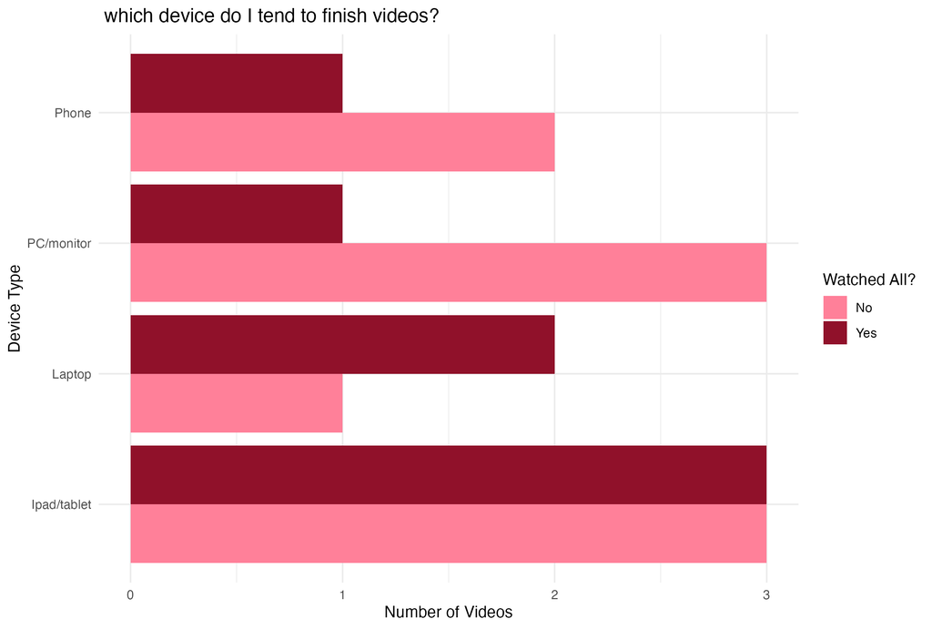

*Figure 4:* **This shows the number of the videos I watched and what device I watched them on, along with if I finished the videos or not.**

This shows that I tend to watch videos on my iPad! I tend to pick up my phone less for watching YouTube. There does not seem to be any relationship between what device i watched and if i finished the video or not.

The larger screens make sense as my laptop and iPad is my “study” devices over TV or phone, so this aligns with the previous plots where I tended to watch videos on weekdays.

[figure not shown]

Gif of a orange cat watching something on a laptop, the cat is stationary but there are floating hearts that are moving

## THE END!!!!!

Thank you for reading!!!!!!!